# Reproducible Research: Peer Assessment 1

## Introduction

The data is from a personal activity monitoring device that collects data at 5 minute intervals through out the day. The data consists of two months of data during the months of October and November, 2012 and include the number of steps taken in 5 minute intervals each day. Activity monitoring data [52K] The variables included in this dataset are:

- steps: Number of steps taking in a 5-minute interval (missing values are coded as NA)
- date: The date on which the measurement was taken in YYYY-MM-DD format
- interval: Identifier for the 5-minute interval in which measurement was taken The dataset is stored in a comma-separated-value (CSV) file and there are a total of 17,568 observations in this dataset.

## Loading and preprocessing the data

```r
unzip(zipfile="activity.zip")
data <- read.csv("activity.csv")
data$date  <- as.Date.character(data$date)
```

## Mean and median number of steps taken each day

### What is mean total number of steps taken per day?

##### 1. Calculate the total number of steps taken per day (ignore the missing values in the dataset.)

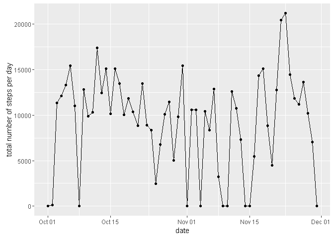

```r
library(ggplot2)
dailySteps <- aggregate(x=list(steps=data$steps), by=list(date=data$date), FUN=sum, na.rm=TRUE)

ggplot(data=dailySteps, aes(x=date, y=steps)) +  geom_point() +
  geom_line() +
  xlab("date") +
  ylab("total number of steps per day")
```

##### 2. Make a histogram of the total number of steps taken each day

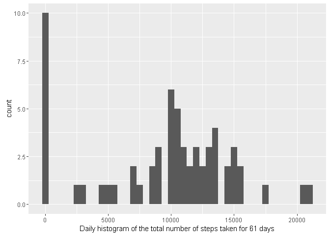

```r
steps_per_day <- tapply(data$steps, data$date, FUN=sum, na.rm=TRUE)
qplot(steps_per_day, binwidth=500, xlab="Daily histogram of the total number of steps taken for 61 days")
```

```r
dailyMean <- mean(dailySteps$steps, na.rm=TRUE)
dailyMedian <- median(dailySteps$steps, na.rm=TRUE)
```

##### 3. Mean and median number of steps taken each day:

- The average daily steps is 9354.2295082, the median daily steps is 10395.

## What is the average daily activity pattern?

##### 1. Make a time series plot of the average number of steps taken

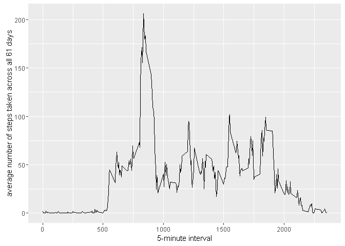

```r
dailyAverages <- aggregate(x=list(steps=data$steps), by=list(interval=data$interval), FUN=mean, na.rm=TRUE)
dailyAverages$intervalTime  <- gsub("([0-9]{1,2})([0-9]{2})", "\\1:\\2", dailyAverages$interval)
ggplot(data=dailyAverages, aes(x=interval, y=steps)) +
  geom_line() +
  xlab("5-minute interval") +
  ylab("average number of steps taken across all 61 days")
```

##### 2. On average which 5-minute interval contains the maximum number of steps?

```r
maxStep <- dailyAverages[which.max(dailyAverages$steps),]
```

The max step 206 happened at 8:35 of the day

## Imputing missing values

Code to describe and show a strategy for imputing missing data

##### 1. Calculate and report the total number of missing values in the dataset (i.e. the total number of rows with NAs)

```r
missingSteps <- length(which(is.na(data$steps)))
```

- There are 2304 number of missing values.

##### 3. Create a new dataset that is equal to the original dataset but with the missing data filled in.

```r
library(Hmisc)
imputedData <- data
imputedData$steps <- impute(data$steps, fun=mean)
```

##### 4. Plot histogram of the total number of steps taken each day after missing values are imputed

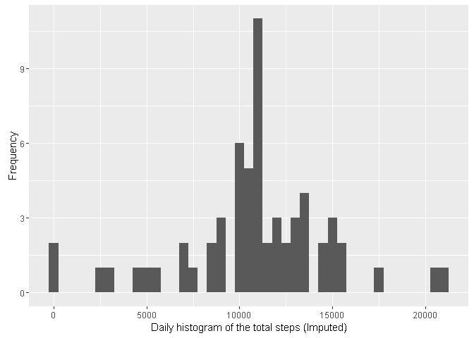

```r
stepsImputedDaily <- tapply(imputedData$steps, imputedData$date, sum)
qplot(stepsImputedDaily, xlab='Daily histogram of the total steps (Imputed)', ylab='Frequency', binwidth=500)
```

```r
round(mean(stepsImputedDaily))
```

```
## [1] 10766
```

```r
meanImputedStep <- as.character(round(mean(stepsImputedDaily)))
medianImputedStep <- round(median(stepsImputedDaily))
```

## Are there differences in activity patterns between weekdays and weekends?

Panel plot comparing the average number of steps taken per 5-minute interval across weekdays and weekends

##### 1. Create a new factor variable in the dataset with two levels – “weekday” and “weekend” indicating whether a given date is a weekday or weekend day.

```r
imputedData$dayType <-  ifelse(as.POSIXlt(imputedData$date)$wday %in% c(0,6), 'weekend', 'weekday')
```

##### 2. Make a panel plot containing a time series plot

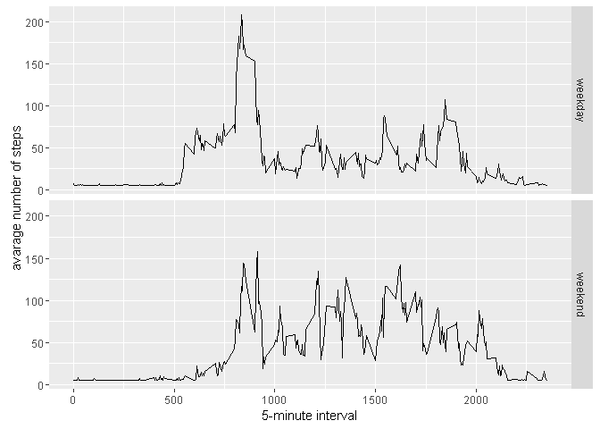

```r
averagedimputedData <- aggregate(steps ~ interval + dayType, data=imputedData, mean)
ggplot(averagedimputedData, aes(interval, steps)) +
  geom_line() +
  facet_grid(dayType ~ .) +
  xlab("5-minute interval") +
  ylab("avarage number of steps")
```